# Consistency Analysis

Einar Pétur Jónsson

2026-02-19

```r
library(readxl)
library(ggplot2)
library(ggpattern)
library(dplyr)
library(car)
```

# Data preparation

```r
# Controls — single and multi both sourced from tempctrl file
ctrl_data <- read_excel("consistency_tempctrl.xlsx") %>%
  mutate(
    group      = "Reference",
    experiment = ifelse(grepl("single", experiment), "single", "multi")
  )

# Treatments
dataTtreat  <- read_excel("consistency_temptreat.xlsx") %>%
  mutate(group = "Temperature",
         experiment = ifelse(grepl("single", experiment), "single", "multi"))

datapHtreat <- read_excel("consistency_pHtreat.xlsx") %>%
  mutate(group = "pH",
         experiment = ifelse(grepl("single", experiment), "single", "multi"))

dataLitreat <- read_excel("consistency_Litreat.xlsx") %>%
  mutate(group = "Lithium",
         experiment = ifelse(grepl("single", experiment), "single", "multi"))

# Combine and set factor levels
all_data <- bind_rows(ctrl_data, dataTtreat, datapHtreat, dataLitreat) %>%
  mutate(
    experiment = as.factor(experiment),
    group      = factor(group, levels = c("Reference", "Temperature", "pH", "Lithium")),
    group_exp  = factor(paste(group, experiment, sep = "_"),
                        levels = c("Reference_single", "Reference_multi",
                                   "Temperature_single", "Temperature_multi",
                                   "pH_single", "pH_multi",
                                   "Lithium_single", "Lithium_multi"))
  )
```

# Plot

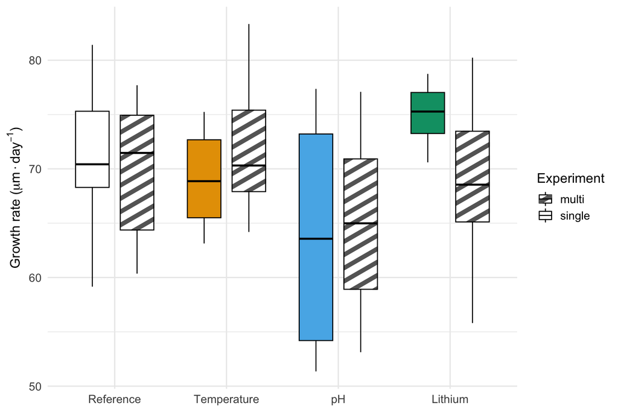

```r
fill_map <- c(
  "Reference_single"   = "white",
  "Reference_multi"    = "white",
  "Temperature_single" = "#E69F00",
  "Temperature_multi"  = "white",
  "pH_single"          = "#56B4E9",
  "pH_multi"           = "white",
  "Lithium_single"     = "#009E73",
  "Lithium_multi"      = "white"
)

y_label <- expression(paste("Growth rate ("*mu*"m"%.%"day"^-1*")"))

shared_theme <- theme_minimal(base_size = 14) +
  theme(
    axis.text     = element_text(size = 12),
    axis.title.y  = element_text(size = 14),
    legend.text   = element_text(size = 12),
    legend.title  = element_text(size = 14),
    legend.position = "right"
  )

p <- ggplot(all_data, aes(x = group, y = growth_rate,
                           fill = group_exp, pattern = experiment)) +
  geom_boxplot_pattern(
    position        = position_dodge(width = 0.8),
    width           = 0.6,
    pattern_fill    = "gray40",
    pattern_colour  = "gray40",
    pattern_density = 0.3,
    pattern_spacing = 0.03,
    colour          = "black"
  ) +
  scale_fill_manual(values = fill_map, guide = "none") +
  scale_pattern_manual(
    values = c("single" = "none", "multi" = "stripe"),
    name   = "Experiment"
  ) +
  labs(x = NULL, y = y_label) +
  shared_theme

p
```

```r
# Save as PNG
ggsave("consistency_plot.png", plot = p, width = 9, height = 6, dpi = 300)
```

# Statistical comparisons

For each group, the pipeline: (1) tests normality with Shapiro-Wilk, (2) tests homogeneity of variance with Levene’s test, and (3) selects the appropriate comparison test — Student’s t-test if both groups are normal with homogeneous variance, Welch’s t-test if normal but with heterogeneous variance, or a Wilcoxon rank-sum test if normality is violated.

```r
groups <- c("Reference", "Temperature", "pH", "Lithium")

for (g in groups) {

  cat("\n## ", g, "\n\n")

  df <- all_data %>% filter(group == g)

  # --- Shapiro-Wilk ---
  cat("### Normality (Shapiro-Wilk)\n\n")
  sw_results <- list()
  for (exp in c("single", "multi")) {
    vals <- df %>% filter(experiment == exp) %>% pull(growth_rate)
    sw   <- shapiro.test(vals)
    sw_results[[exp]] <- sw$p.value
    cat("**", exp, "**: W =", round(sw$statistic, 4),
        ", p =", round(sw$p.value, 4),
        ifelse(sw$p.value > 0.05, " — Normal\n\n", " — NOT normal\n\n"))
  }

  # --- Levene's test ---
  cat("### Homogeneity of variance (Levene's test)\n\n")
  lev <- leveneTest(growth_rate ~ experiment, data = df)
  lev_p <- lev$`Pr(>F)`[1]
  cat("p =", round(lev_p, 4),
      ifelse(lev_p > 0.05, " — Homogeneous variance\n\n",
                            " — Variance NOT homogeneous\n\n"))

  # --- Choose test ---
  both_normal <- all(unlist(sw_results) > 0.05)
  homogeneous <- lev_p > 0.05

  cat("### Comparison test\n\n")
  if (both_normal & homogeneous) {
    cat("Both groups normal and variance homogeneous — **Student's t-test**\n\n")
    result <- t.test(growth_rate ~ experiment, data = df, var.equal = TRUE)
  } else if (both_normal & !homogeneous) {
    cat("Both groups normal but variance heterogeneous — **Welch's t-test**\n\n")
    result <- t.test(growth_rate ~ experiment, data = df, var.equal = FALSE)
  } else {
    cat("Normality violated — **Wilcoxon rank-sum test**\n\n")
    result <- wilcox.test(growth_rate ~ experiment, data = df)
  }

  print(result)
  cat("\n---\n")
}
```

## Reference

### Normality (Shapiro-Wilk)

** single **: W = 0.9797 , p = 0.8179 — Normal

** multi **: W = 0.8562 , p = 0.0085 — NOT normal

### Homogeneity of variance (Levene’s test)

p = 0.4178 — Homogeneous variance

### Comparison test

Normality violated — **Wilcoxon rank-sum test**

```
Wilcoxon rank sum exact test
```

data: growth_rate by experiment W = 248, p-value = 0.4576 alternative hypothesis: true location shift is not equal to 0

## Temperature

### Normality (Shapiro-Wilk)

** single **: W = 0.9439 , p = 0.6904 — Normal

** multi **: W = 0.8955 , p = 0.034 — NOT normal

### Homogeneity of variance (Levene’s test)

p = 0.6767 — Homogeneous variance

### Comparison test

Normality violated — **Wilcoxon rank-sum test**

```
Wilcoxon rank sum exact test
```

data: growth_rate by experiment W = 75, p-value = 0.3875 alternative hypothesis: true location shift is not equal to 0

## pH

### Normality (Shapiro-Wilk)

** single **: W = 0.8791 , p = 0.1535 — Normal

** multi **: W = 0.9661 , p = 0.7967 — Normal

### Homogeneity of variance (Levene’s test)

p = 0.1493 — Homogeneous variance

### Comparison test

Both groups normal and variance homogeneous — **Student’s t-test**

```
Two Sample t-test
```

data: growth_rate by experiment t = 0.17652, df = 22, p-value = 0.8615 alternative hypothesis: true difference in means between group multi and group single is not equal to 0 95 percent confidence interval: -6.780533 8.042200 sample estimates: mean in group multi mean in group single 65.19833 64.56750

## Lithium

### Normality (Shapiro-Wilk)

** single **: W = 0.9384 , p = 0.5349 — Normal

** multi **: W = 0.969 , p = 0.7794 — Normal

### Homogeneity of variance (Levene’s test)

p = 0.0383 — Variance NOT homogeneous

### Comparison test

Both groups normal but variance heterogeneous — **Welch’s t-test**

```
Welch Two Sample t-test
```

data: growth_rate by experiment t = -3.464, df = 24.828, p-value = 0.001946 alternative hypothesis: true difference in means between group multi and group single is not equal to 0 95 percent confidence interval: -9.910879 -2.518399 sample estimates: mean in group multi mean in group single 68.62211 74.83675